# Getting steady-state in SO trait model

Check what the w_min values were adjusted to for small divers and leopard seals

```r
groups$w_min
```

```
 [1] 6.310000e-05 1.000000e-03 6.969100e-04 3.591364e-03 4.000000e+01 4.500000e+03 3.591364e-03 3.351032e-02 2.000000e+05 1.000000e+04
[11] 1.350000e+05 6.000000e+05 4.900000e+05 3.650000e+06 2.250000e+06
```

```r
params_v1@species_params$w_min
```

```
 [1] 6.310000e-05 1.000000e-03 6.969100e-04 3.591364e-03 4.000000e+01 1.000000e-03 3.591364e-03 3.351032e-02 1.000000e-03 1.000000e+04
[11] 1.350000e+05 6.000000e+05 4.900000e+05 3.650000e+06 2.250000e+06
```

```r
params_v1@species_params$species
```

```
 [1] "euphausiids"              "mesopelagic fishes"       "bathypelagic fishes"      "shelf and coastal fishes" "flying birds"
 [6] "small divers"             "squids"                   "toothfishes"              "leopard seals"            "medium divers"
[11] "large divers"             "minke whales"             "orca"                     "sperm whales"             "baleen whales"
```

```r
params_v2 <- params_v1

params_v2@species_params$w_min[params_v2@species_params$species == "small divers"]  <- params_v2@species_params$w_mat[params_v2@species_params$species == "small divers"] * 0.85
params_v2@species_params$w_min[params_v2@species_params$species == "leopard seals"]  <- params_v2@species_params$w_mat[params_v2@species_params$species == "leopard seals"] * 0.85

params_v2 <- setParams(params_v2)
```

Check to make sure setParams didn’t change the adjusted w_min values

```r
groups$w_min
```

```
 [1] 6.310000e-05 1.000000e-03 6.969100e-04 3.591364e-03 4.000000e+01 4.500000e+03 3.591364e-03 3.351032e-02 2.000000e+05 1.000000e+04
[11] 1.350000e+05 6.000000e+05 4.900000e+05 3.650000e+06 2.250000e+06
```

```r
params_v2@species_params$w_min
```

```
 [1] 6.310000e-05 1.000000e-03 6.969100e-04 3.591364e-03 4.000000e+01 3.626667e+03 3.591364e-03 3.351032e-02 2.662200e+05 1.000000e+04
[11] 1.350000e+05 6.000000e+05 4.900000e+05 3.650000e+06 2.250000e+06
```

```r
params_v2@species_params$w_mat
```

```
 [1] 1.584893e-02 1.127500e+01 6.255000e+01 4.675000e+01 1.718542e+03 4.266667e+03 1.280543e+02 1.276520e+04 3.132000e+05 2.947500e+05
[11] 1.821600e+06 5.400000e+06 4.900000e+06 3.285000e+07 5.070000e+07
```

```r
params_v2@species_params$species
```

```
 [1] "euphausiids"              "mesopelagic fishes"       "bathypelagic fishes"      "shelf and coastal fishes" "flying birds"
 [6] "small divers"             "squids"                   "toothfishes"              "leopard seals"            "medium divers"
[11] "large divers"             "minke whales"             "orca"                     "sperm whales"             "baleen whales"
```

Add in box feeding kernel for the baleen whales max ppmr value are based on w_max baleen whale feeding on w_min euphausiids min ppmr value based on w_min baleen whale feeding on w_max euphausiids

```r
params_v2@species_params$w_min[params_v2@species_params$species == "baleen whales"]
```

```
[1] 2250000
```

```r
params_v2@species_params$w_max[params_v2@species_params$species == "baleen whales"]
```

```
[1] 1.03e+08
```

```r
params_v2@species_params$w_min[params_v2@species_params$species == "euphausiids"]
```

```
[1] 6.31e-05
```

```r
params_v2@species_params$w_max[params_v2@species_params$species == "euphausiids"]
```

```
[1] 3.162278
```

```r
params_v2 <- params
```

```r
# 1.03e+08/6.31e-05 # w_max baleen whale divided by w_min euphausiids
# 2250000/3.162278 # w_min baleen whale divided by w_max euphausiids

# params_v2@species_params$ppmr_min[params_v2@species_params$species == "baleen whales"]  <- 711512.4
# params_v2@species_params$ppmr_max[params_v2@species_params$species == "baleen whales"] <- 1.63233e+12
# params_v2@species_params$ppmr_min[params_v2@species_params$species == "baleen whales"]  <- 711512.4
# params_v2@species_params$ppmr_max[params_v2@species_params$species == "baleen whales"] <- 1e+10
params_v2@species_params$ppmr_min[params_v2@species_params$species == "baleen whales"]  <- 1e5
params_v2@species_params$ppmr_max[params_v2@species_params$species == "baleen whales"] <-5e7
params_v2@species_params$pred_kernel_type[params_v2@species_params$species == "baleen whales"] <- "box"
```

```r
params_v2 <- setParams(params_v2)

params_v2@resource_params$w_pp_cutoff
```

```
[1] 10000
```

Correct R_max for the kappa value

```r
params_sim <- params_v2

params_sim@species_params$R_max <- params_sim@resource_params$kappa*params_sim@species_params$w_max^-1.5

params_sim <- setParams(params_sim)

sim <- project(params_sim, effort=0, t_max = 500)
```

[output not shown]

[output cut: 91 more lines]

[output not shown]

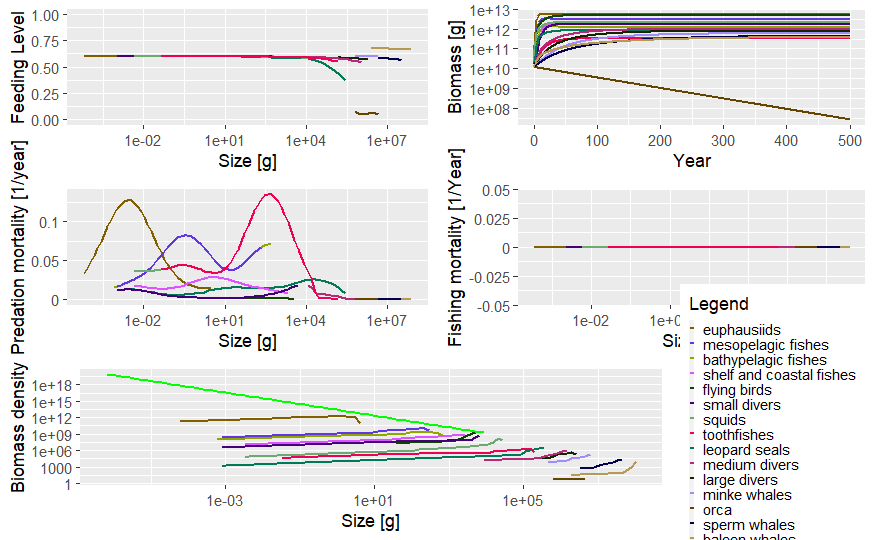

```r
plot(sim)
```

```r
params_steady_v1 <- steady(params_sim)
```

Some species don’t appear to be getting enough food, especially orca. Increase gamma to see if this improves things

```r
params_sim_v2 <- params_sim
params_sim_v2@species_params$gamma[params_sim_v2@species_params$species == "orca"] <- params_sim@species_params$gamma[params_sim@species_params$species == "orca"] * 50
```

```r
sim_v2 <- project(params_sim_v2, effort=0, t_max = 1000)
```

[output not shown]

[output cut: 123 more lines]

[output not shown]

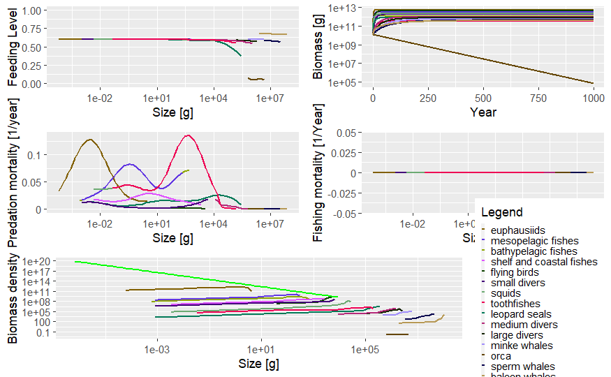

```r
plot(sim_v2)
```

```r
# params_tuned_v1 <- tuneGrowth(params_sim_v2)
params_tuned_v1 <- tuneParams(params_sim_v2)
```

```r
sim_tuned_v1 <- project(params_tuned_v1, effort=0, t_max = 500)
```

```
Error in is(object, "MizerSim") : object 'params_tuned_v1' not found
```

```r
params_tuned_v2 <- steady(params_tuned_v1)

params_tuned_v3 <- tuneParams(params_tuned_v2)
```